# Data representation with R I

Principles and the grammar of graphics

O Rodriguez de Rivera Ortega, PhD

University of Exeter

# 1 Session overview

## 1.1 Learning outcomes

- choose an appropriate graph for categorical, quantitative, temporal and spatial data;
- build plots in layers using the grammar of graphics;
- use colour, faceting, shape, size and transparency deliberately;
- spot common visualisation problems: misleading scales, clutter, overplotting and poor labels;
- produce publication-ready graphics using `ggplot2`.

# 2 Setup

## 2.1 Packages used in this practical

Run this once before the practical if packages are not already installed.

```r
install.packages(c(
  "tidyverse", "palmerpenguins", "gapminder", "datasauRus",
  "patchwork", "scales", "viridis", "maps", "GGally", "plotly"
))
```

The practical mostly uses package datasets, so it does not depend on internet access once packages are installed.

```r
library(tidyverse)
library(palmerpenguins)
library(scales)

theme_set(theme_minimal(base_size = 12))
```

## 2.2 Example datasets

We will use:

- `palmerpenguins::penguins`: ecological measurements from three penguin species;
- `gapminder::gapminder`: country-level time series for population, GDP per capita and life expectancy;
- `datasauRus::datasaurus_dozen`: a reminder that summary statistics alone can be misleading;
- `ggplot2::mpg` and `ggplot2::economics`: built-in examples for additional practice.

```r
penguins_clean <- penguins %>%
  drop_na(species, island, bill_length_mm, bill_depth_mm,
          flipper_length_mm, body_mass_g, sex)

glimpse(penguins_clean)
```

```
## Rows: 333
## Columns: 8
## $ species           <fct> Adelie, Adelie, Adelie, Adelie, Adelie, Adelie, Adel…
## $ island            <fct> Torgersen, Torgersen, Torgersen, Torgersen, Torgerse…
## $ bill_length_mm    <dbl> 39.1, 39.5, 40.3, 36.7, 39.3, 38.9, 39.2, 41.1, 38.6…
## $ bill_depth_mm     <dbl> 18.7, 17.4, 18.0, 19.3, 20.6, 17.8, 19.6, 17.6, 21.2…
## $ flipper_length_mm <int> 181, 186, 195, 193, 190, 181, 195, 182, 191, 198, 18…
## $ body_mass_g       <int> 3750, 3800, 3250, 3450, 3650, 3625, 4675, 3200, 3800…
## $ sex               <fct> male, female, female, female, male, female, male, fe…
## $ year              <int> 2007, 2007, 2007, 2007, 2007, 2007, 2007, 2007, 2007…
```

# 3 Why visualise data?

## 3.1 Visualisation is not decoration

A good graph helps us to answer a question.

Before plotting, ask:

1. What is the question?
2. What type of variables do I have?
3. What comparison or pattern should the reader see first?
4. What should be removed because it distracts from that pattern?

## 3.2 Same summaries, different patterns

The Datasaurus Dozen contains datasets with very similar means, standard deviations and correlations, but very different visual patterns.

```r
library(datasauRus)

datasaurus_dozen %>%
  group_by(dataset) %>%
  summarise(
    mean_x = mean(x),
    mean_y = mean(y),
    sd_x = sd(x),
    sd_y = sd(y),
    correlation = cor(x, y),
    .groups = "drop"
  ) %>%
  slice(1:6)
```

| dataset | mean_x | mean_y | sd_x | sd_y | correlation |
| --- | --- | --- | --- | --- | --- |
| away | 54.26610 | 47.83472 | 16.76982 | 26.93974 | -0.06412835 |
| bullseye | 54.26873 | 47.83082 | 16.76924 | 26.93573 | -0.06858639 |
| circle | 54.26732 | 47.83772 | 16.76001 | 26.93004 | -0.06834336 |
| dino | 54.26327 | 47.83225 | 16.76514 | 26.93540 | -0.06447185 |
| dots | 54.26030 | 47.83983 | 16.76774 | 26.93019 | -0.06034144 |
| h_lines | 54.26144 | 47.83025 | 16.76590 | 26.93988 | -0.06171484 |

## 3.3 Plot the data

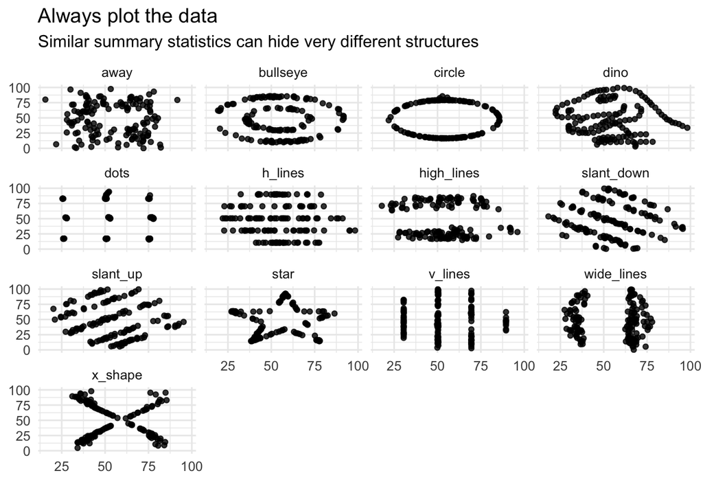

```r
ggplot(datasaurus_dozen, aes(x = x, y = y)) +
  geom_point(alpha = 0.8, size = 1.4) +
  facet_wrap(~ dataset, ncol = 4) +
  labs(
    title = "Always plot the data",
    subtitle = "Similar summary statistics can hide very different structures",
    x = NULL,
    y = NULL
  )
```

## 3.4 Common problems

- **Ugly:** aesthetic choices make the plot hard to read, but the message is still correct.
- **Bad:** perceptual choices make the plot confusing or misleading.
- **Wrong:** the plot is mathematically incorrect or the visual encoding contradicts the data.

Examples:

- bar charts with a truncated y-axis;
- colour scales that imply order where none exists;
- 3D pie charts;
- too many groups in one panel;
- legends and labels that do not explain units.

# 4 The grammar of graphics

## 4.1 Anatomy of a `ggplot2` graph

A `ggplot2` graph is built from layers:

```r
ggplot(data = DATA, mapping = aes(x = X, y = Y)) +
  GEOM_FUNCTION() +
  SCALE_FUNCTION() +
  COORDINATE_FUNCTION() +
  FACET_FUNCTION() +
  THEME_FUNCTION()
```

Core components:

- **data:** the dataset;
- **aesthetics:** mapping variables to visual features;
- **geometries:** points, lines, bars, boxes, polygons;
- **scales:** colour, size, axis transformations;
- **facets:** small multiples;
- **themes:** non-data appearance.

## 4.2 Start with a mapping

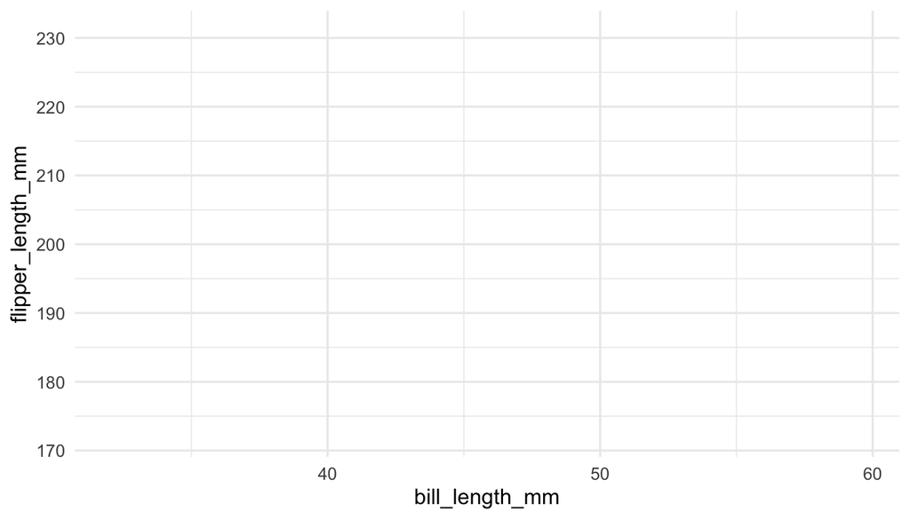

```r
ggplot(
  data = penguins_clean,
  mapping = aes(x = bill_length_mm, y = flipper_length_mm)
)
```

The plot is empty because we have said **what variables to use**, but not **how to draw them**.

## 4.3 Add a geometry

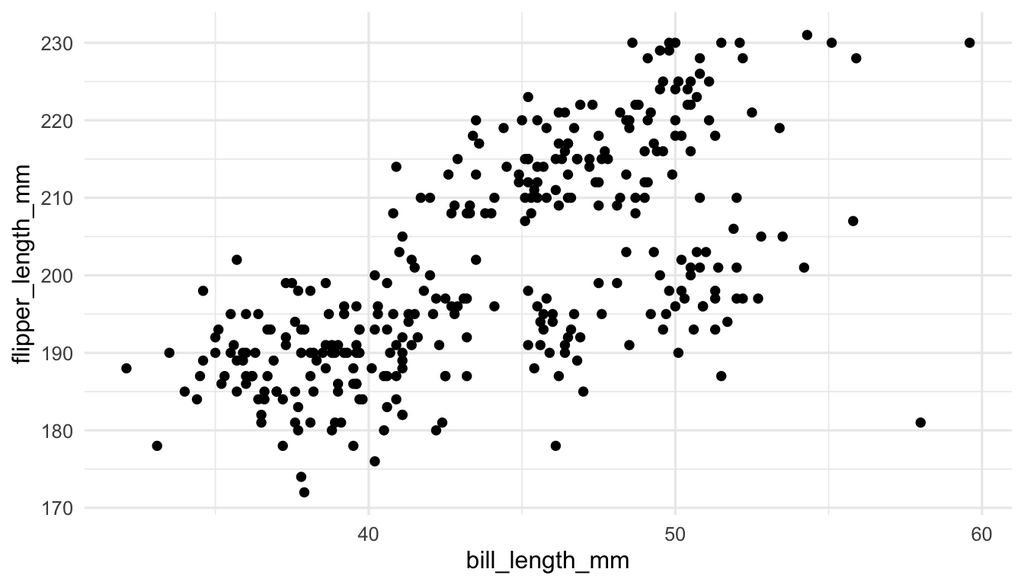

```r
ggplot(penguins_clean, aes(x = bill_length_mm, y = flipper_length_mm)) +
  geom_point()
```

## 4.4 Improve readability

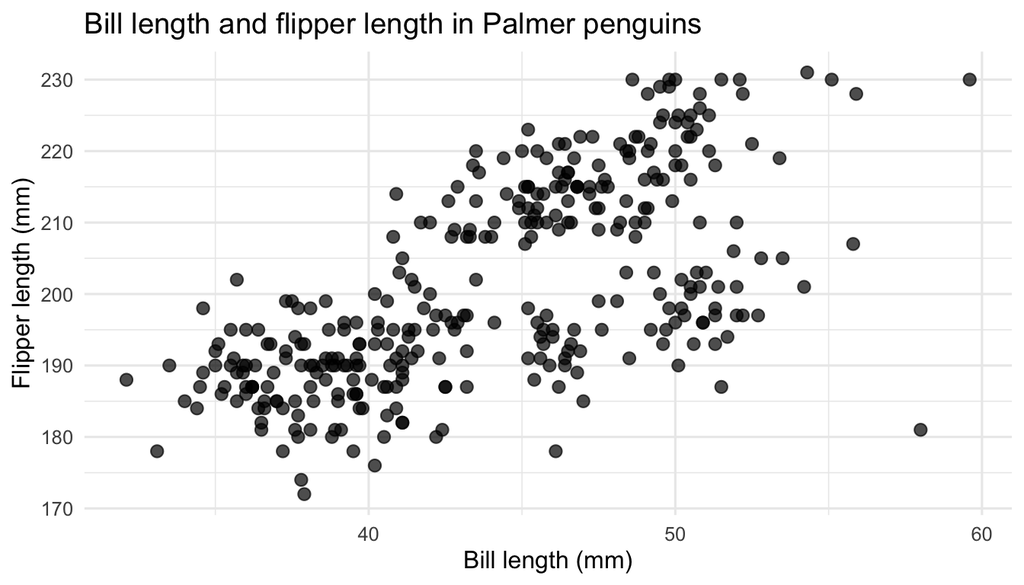

```r
ggplot(penguins_clean, aes(x = bill_length_mm, y = flipper_length_mm)) +
  geom_point(alpha = 0.7, size = 2.5) +
  labs(
    title = "Bill length and flipper length in Palmer penguins",
    x = "Bill length (mm)",
    y = "Flipper length (mm)"
  )
```

## 4.5 Map species to colour

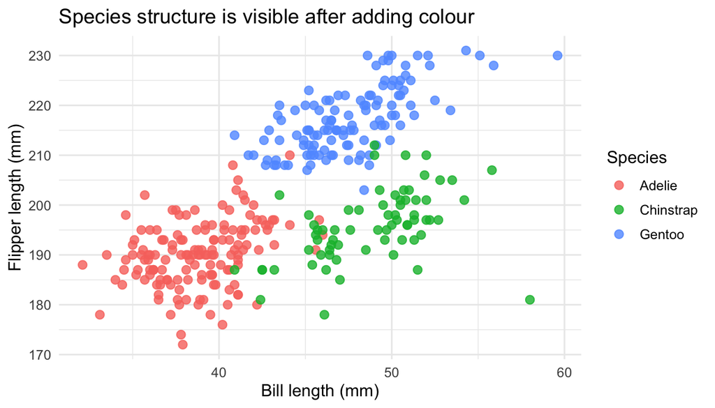

```r
ggplot(penguins_clean,
       aes(x = bill_length_mm, y = flipper_length_mm, colour = species)) +
  geom_point(alpha = 0.8, size = 2.5) +
  labs(
    title = "Species structure is visible after adding colour",
    x = "Bill length (mm)",
    y = "Flipper length (mm)",
    colour = "Species"
  )
```

## 4.6 Add a trend carefully

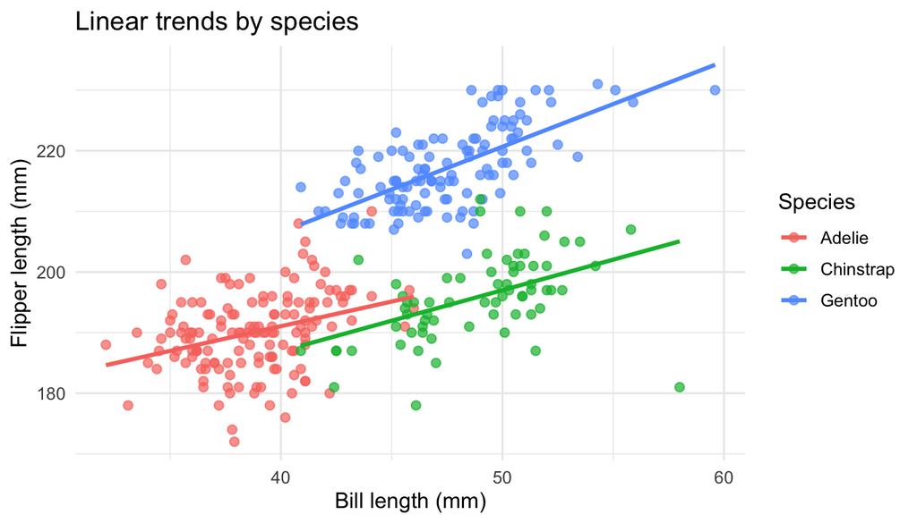

```r
ggplot(penguins_clean,
       aes(x = bill_length_mm, y = flipper_length_mm, colour = species)) +
  geom_point(alpha = 0.7, size = 2) +
  geom_smooth(method = "lm", se = FALSE) +
  labs(
    title = "Linear trends by species",
    x = "Bill length (mm)",
    y = "Flipper length (mm)",
    colour = "Species"
  )
```

## 4.7 Facet into small multiples

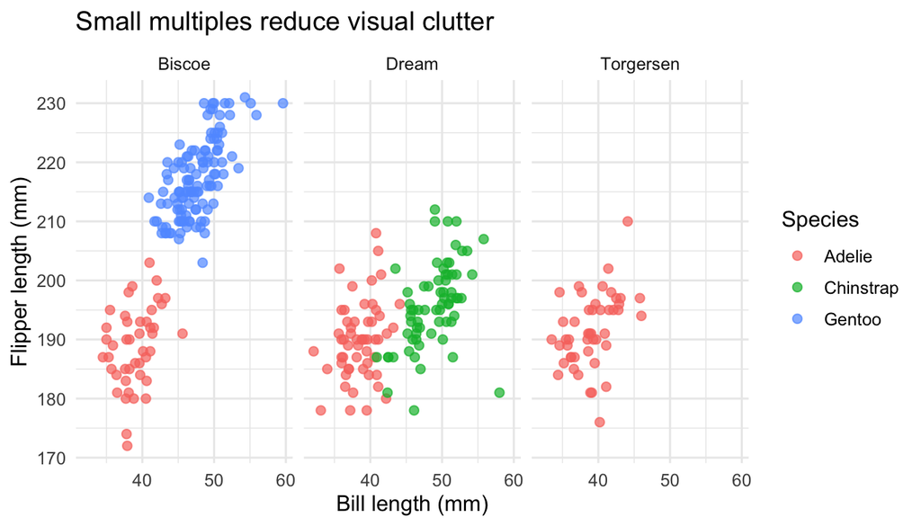

```r
ggplot(penguins_clean,
       aes(x = bill_length_mm, y = flipper_length_mm, colour = species)) +
  geom_point(alpha = 0.7, size = 2) +
  facet_wrap(~ island) +
  labs(
    title = "Small multiples reduce visual clutter",
    x = "Bill length (mm)",
    y = "Flipper length (mm)",
    colour = "Species"
  )
```

# 5 Design principles

## 5.1 Match plot type to variable type

| Variable relationship | Useful plots |
| --- | --- |
| One categorical variable | bar chart |
| One quantitative variable | histogram, density, dotplot, boxplot |
| Categorical vs quantitative | boxplot, violin, jittered points |
| Quantitative vs quantitative | scatterplot, smooth, hexbin |
| Time vs quantitative | line plot |
| Space | point map, choropleth, raster/heatmap |
| Many variables | facets, colour/shape/size, PCA, heatmap |

## 5.2 Design checklist

Before showing a graph, check:

- Does the title state the main message?
- Are axes labelled with units?
- Does the legend use clear names?
- Is colour necessary and accessible?
- Is there overplotting?
- Are scales honest? For bars, zero should normally be visible.
- Is the graph simpler than the table it replaces?

# 6 Short exercise

## 6.1 Exercise 1: build a plot in layers

Use `penguins_clean` and create a plot showing the relationship between `body_mass_g` and `flipper_length_mm`.

Tasks:

1. Start with `ggplot()` and a mapping.
2. Add points.
3. Colour by `species`.
4. Add a linear trend.
5. Add informative labels.
6. Facet by `sex`.

## 6.2 Discussion

After completing the exercise, discuss:

- What is the main pattern?
- Does the pattern differ by species or sex?
- Is colour or faceting doing more useful work?
- What would you change before using the graph in a report?